# Cross-validation of regression models: mixed model examples (edited v3)

John Fox and Georges Monette

2023-10-18

### Example: Contrived Hierarchical Data

We introduce an artificial data set that exemplifies aspects of cross-validation particular to hierarchical models. Using this data set, we show that model comparisons employing cluster-based and those employing case-based cross-validation may not agree on a “best” model. Furthermore, commonly used measures of fit, such as mean-squared error, do not necessarily become smaller as models become larger, even when the models are nested, and even when the measure of fit is computed for the whole data set.

The researcher, who has more expertise in yodelling than in modelling, decides to model the response, $y$, yodelling skill, as a function of age, $x$, reasoning that students get older during their stay in the program, and (incorrectly) that age can serve as a proxy for elapsed time. The researcher knows that a mixed model should be used to account for clustering due to the expected similarity of measurements taken from each student.

We start by generating the data, using parameters consistent with the description above and meant to highlight the issues that arise in cross-validating mixed-effects models:[^1]

```r
# Parameters:
set.seed(9693)
Nb <- 100     # number of groups
Nw <- 5       # number of individuals within groups
Bb <- 0       # between-group regression coefficient on group mean
SDre <- 2.0   # between-group SD of random level relative to group mean of x
SDwithin <- 0.5  # within group SD
Bw <- 1          # within group effect of x
Ay <- 10         # intercept for response
Ax <- 20         # starting level of x
Nx <- Nw*10      # number of distinct x values

Data <- data.frame(
  group = factor(rep(1:Nb, each=Nw)),
  x = Ax + rep(1:Nx, length.out = Nw*Nb)
) |>
  within(
    {
      xm  <- ave(x, group, FUN = mean) # within-group mean
      y <- Ay +
        Bb * xm +                    # contextual effect
        Bw * (x - xm) +              # within-group effect
        rnorm(Nb, sd=SDre)[group] +  # random level by group
        rnorm(Nb*Nw, sd=SDwithin)    # random error within groups
    }
  )
```

Here is scatterplot of the data for a representative group of 10 (without loss of generality, the first 10) of 100 students, showing the 95% concentration ellipse for each cluster:[^2]

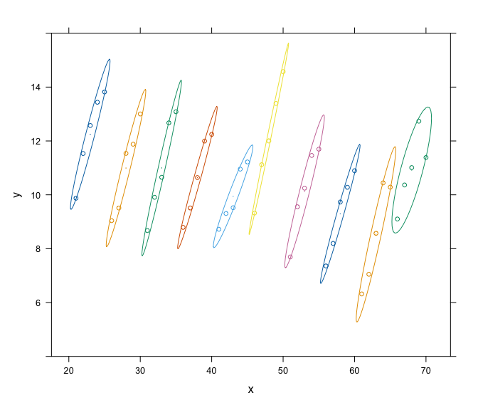

Hierarchical data set, showing the first 10 of 100 students.

```r
library("lattice")
library("latticeExtra")
plot <- xyplot(y ~ x, data=Data[1:Nx, ], group=group,
               ylim=c(4, 16),
               par.settings=list(superpose.symbol=list(pch=1, cex=0.7))) +
    layer(panel.ellipse(..., center.cex=0))
plot # display graph
```

The between-student effect of age is 0 but the within-student effect is 1. Due to the large variation in ages between students, the least-squares regression of yodelling skill on age (for the 500 observations among all 100 students) produces an estimated slope close to 0 (though with a small $p$-value), because the slope is heavily weighted toward the between-student effect:

```r
summary(lm(y ~ x, data=Data))

     Call:
     lm(formula = y ~ x, data = Data)

     Residuals:
        Min     1Q Median     3Q    Max
     -5.771 -1.658 -0.089  1.552  7.624

     Coefficients:
                 Estimate Std. Error t value Pr(>|t|)
     (Intercept)  9.05043    0.34719   26.07   <2e-16
     x            0.02091    0.00727    2.87   0.0042

     Residual standard error: 2.35 on 498 degrees of freedom
     Multiple R-squared:  0.0163,   Adjusted R-squared:  0.0143
     F-statistic: 8.26 on 1 and 498 DF,  p-value: 0.00422
```

The initial mixed-effects model that we fit to the data is a simple random-intercepts model:

```r
# random intercept only:
mod.0 <- lmer(y ~ 1 + (1 | group), Data)
summary(mod.0)
     Linear mixed model fit by REML ['lmerMod']
     Formula: y ~ 1 + (1 | group)
        Data: Data

     REML criterion at convergence: 2103.1

     Scaled residuals:
         Min      1Q  Median      3Q     Max
     -2.0351 -0.7264 -0.0117  0.7848  2.0438

     Random effects:
      Groups   Name        Variance Std.Dev.
      group    (Intercept) 2.90     1.70
      Residual             2.71     1.65
     Number of obs: 500, groups:  group, 100

     Fixed effects:
                 Estimate Std. Error t value
     (Intercept)   10.002      0.186    53.9
```

We will shortly consider three other, more complex, mixed models; because of data-management considerations, it is convenient to fit them now, but we defer discussion of these models:

```r
# effect of x and random intercept:
mod.1 <- lmer(y ~ x + (1 | group), Data)

# effect of x, contextual (student) mean of x, and random intercept:
mod.2 <- lmer(y ~ x + xm + (1 | group), Data)
        # equivalent to y ~ I(x - xm) + xm + (1 | group)

# model generating the data (where Bb = 0)
mod.3 <- lmer(y ~ I(x - xm) + (1 | group), Data)
```

We proceed to obtain predictions from the random-intercept model (`mod.0`) and the other models (`mod.1`, `mod.2`, and `mod.3`) based on fixed effects alone, as would be used for cross-validation based on clusters (i.e., students), and for fixed and random effects—so-called best linear unbiased predictions or BLUPs—as would be used for cross-validation based on cases (i.e., occasions within students):

```r
Data <- within(Data, {
  fit_mod0.fe <- predict(mod.0, re.form = ~ 0) # fixed effects only
  fit_mod0.re <- predict(mod.0) # fixed and random effects (BLUPs)
  fit_mod1.fe <- predict(mod.1, re.form = ~ 0)
  fit_mod1.re <- predict(mod.1)
  fit_mod2.fe <- predict(mod.2, re.form = ~ 0)
  fit_mod2.re <- predict(mod.2)
  fit_mod3.fe <- predict(mod.3, re.form = ~ 0)
  fit_mod3.re <- predict(mod.3)
})
```

We then prepare the data for plotting:

```r
Data_long <- reshape(Data[1:Nx, ], direction = "long", sep = ".",
              timevar = "effect", varying = grep("\\.", names(Data[1:Nx, ])))
Data_long$id <- 1:nrow(Data_long)
Data_long <- reshape(Data_long, direction = "long", sep = "_",
              timevar = "modelcode",  varying = grep("_", names(Data_long)))
Data_long$model <- factor(
  c("~ 1", "~ 1 + x", "~ 1 + x + xm", "~ 1 + I(x - xm)")
  [match(Data_long$modelcode, c("mod0", "mod1", "mod2", "mod3"))]
)
```

Predictions based on the random-intercept model `mod.0` for the first 10 students are shown in the following graph:

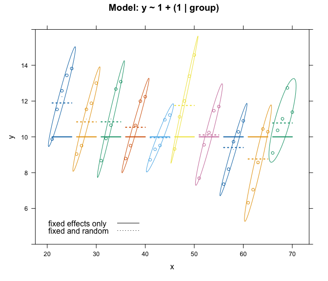

Predictions from the random intercept model.

```r
(plot +
  xyplot(fit ~ x, subset(Data_long, modelcode == "mod0" & effect == "fe"),
         groups=group, type="l", lwd=2) +
  xyplot(fit ~ x, subset(Data_long, modelcode == "mod0" &  effect == "re"),
         groups=group, type="l", lwd=2, lty=3)
) |> update(
  main="Model: y ~ 1 + (1 | group)",
  key=list(
    corner=c(0.05, 0.05),
    text=list(c("fixed effects only","fixed and random")),
    lines=list(lty=c(1, 3))))
```

The fixed-effect predictions for the various individuals are identical—the estimated fixed-effects intercept or estimated general mean of $y$—while the BLUPs are the sums of the fixed-effects intercept and the random intercepts, and are only slightly shrunken towards the general mean. Because in our artificial data there is no population relationship between age and skill, the fixed-effect-only predictions and the BLUPs are not very different.

Our next model, `mod.1`, includes a fixed intercept and fixed effect of `x` along with a random intercept:

```r
summary(mod.1)
     Linear mixed model fit by REML ['lmerMod']
     Formula: y ~ x + (1 | group)
        Data: Data

     REML criterion at convergence: 1564.5

     Scaled residuals:
         Min      1Q  Median      3Q     Max
     -2.9016 -0.6350  0.0188  0.5541  2.8293

     Random effects:
      Groups   Name        Variance Std.Dev.
      group    (Intercept) 192.941  13.890
      Residual               0.257   0.507
     Number of obs: 500, groups:  group, 100

     Fixed effects:
                 Estimate Std. Error t value
     (Intercept) -33.9189     1.5645   -21.7
     x             0.9653     0.0158    61.0

     Correlation of Fixed Effects:
       (Intr)
     x -0.460
```

Predictions from this model appear in the following graph:

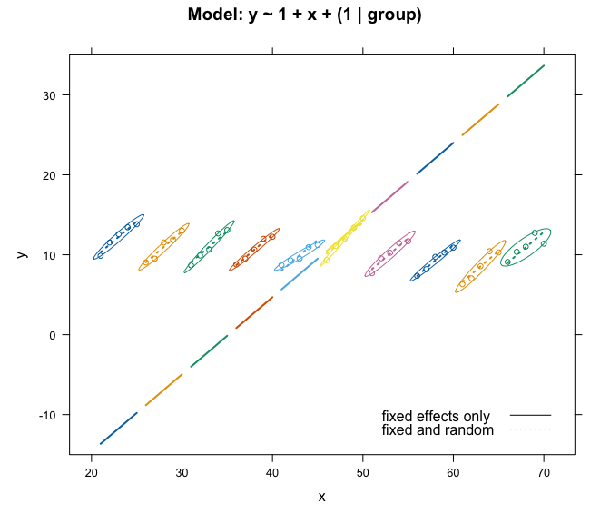

Predictions from the model with random intercepts and $x$ as a fixed-effect predictor.

```r
(plot +
  xyplot(fit ~ x, subset(Data_long, modelcode == "mod1" & effect == "fe"),
         groups=group, type="l", lwd=2) +
  xyplot(fit ~ x, subset(Data_long, modelcode == "mod1" & effect == "re"),
         groups=group, type="l", lwd=2, lty=3)
) |> update(
  main="Model: y ~ 1 + x + (1 | group)",
  ylim=c(-15, 35),
  key=list(
    corner=c(0.95, 0.05),
    text=list(c("fixed effects only","fixed and random")),
    lines=list(lty=c(1, 3))))
```

The BLUPs fit the observed data very closely, but predictions based on the fixed effects alone, with a common intercept and slope for all clusters, are very poor—indeed, much worse than the fixed-effects-only predictions based on the simpler random-intercept model, `mod.0`. We therefore anticipate (and show later in this section) that case-based cross-validation will prefer `mod1` to `mod0`, but that cluster-based cross-validation will prefer `mod0` to `mod1`.

Our third model, `mod.2`, includes the contextual effect of $x$—that is, the cluster mean `xm`—along with $x$ and the intercept in the fixed-effect part of the model, and a random intercept:

```r
summary(mod.2)
     Linear mixed model fit by REML ['lmerMod']
     Formula: y ~ x + xm + (1 | group)
        Data: Data

     REML criterion at convergence: 1169.2

     Scaled residuals:
         Min      1Q  Median      3Q     Max
     -2.9847 -0.6375  0.0019  0.5568  2.7325

     Random effects:
      Groups   Name        Variance Std.Dev.
      group    (Intercept) 3.399    1.844
      Residual             0.255    0.505
     Number of obs: 500, groups:  group, 100

     Fixed effects:
                 Estimate Std. Error t value
     (Intercept)   9.4787     0.6171    15.4
     x             0.9915     0.0160    62.1
     xm           -0.9800     0.0206   -47.7

     Correlation of Fixed Effects:
        (Intr) x
     x   0.000
     xm -0.600 -0.777
```

This model is equivalent to fitting `y ~ I(x - xm) + xm + (1 | group)`, which is the model that generated the data once the coefficient of the contextual predictor `xm` is set to 0 (as it is in `mod.3`, discussed below).

Predictions from model `mod.2` appear in the following graph:

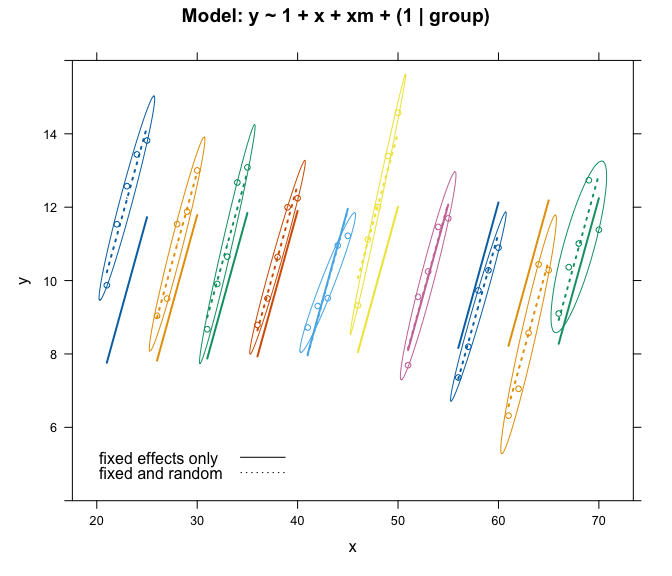

Predictors from the model with random intercepts, $x$, and the group (student) mean of $x$ as predictors.

```r
(plot +
  xyplot(fit ~ x, subset(Data_long, modelcode == "mod2" & effect == "fe"),
         groups=group, type="l", lwd=2) +
  xyplot(fit ~ x, subset(Data_long, modelcode == "mod2" & effect == "re"),
         groups=group, type="l", lwd=2, lty=3)
) |> update(
  main="Model: y ~ 1 + x + xm + (1 | group)",
  ylim=c(4, 16),
  key=list(
    corner=c(0.05, 0.05),
    text=list(c("fixed effects only","fixed and random")),
    lines=list(lty=c(1, 3))))
```

Depending on the estimated variance parameters of the model, a mixed model like `mod.2` will apply varying degrees of shrinkage to the random-intercept BLUPs that correspond to variation in the heights of the parallel fitted lines for the individual students. In our contrived data, the `mod.2` applies little shrinkage, allowing substantial variability in the heights of the fitted lines, which closely approach the observed values for each student. The fit of the mixed model `mod.2` is consequently similar to that of a fixed-effects model with age and a categorical predictor for individual students (i.e., treating students as a factor, and not shown here).

The mixed model `mod.2` therefore fits individual observations well, and we anticipate a favorable assessment using individual-based cross-validation. In contrast, the large variability in the BLUPs results in larger residuals for predictions based on fixed effects alone, and so we expect that cluster-based cross-validation won’t show an advantage for model `mod.2` compared to the smaller model `mod.0`, which includes only fixed and random intercepts.

Had the mixed model applied considerable shrinkage, then neither cluster-based nor case-based cross-validation would show much improvement over the random-intercept-only model. In our experience, the degree of shrinkage does not vary smoothly as parameters are changed but tends to be “all or nothing,” and near the tipping point, the behavior of estimates can be affected considerably by the choice of algorithm used to fit the model.

Finally, `mod.3` directly estimates the model used to generate the data. As mentioned, it is a constrained version of `mod.2`, with the coefficient of `xm` set to 0, and with `x` expressed as a deviation from the cluster mean `xm`:

```r
summary(mod.3)
     Linear mixed model fit by REML ['lmerMod']
     Formula: y ~ I(x - xm) + (1 | group)
        Data: Data

     REML criterion at convergence: 1163.2

     Scaled residuals:
         Min      1Q  Median      3Q     Max
     -2.9770 -0.6320  0.0063  0.5603  2.7249

     Random effects:
      Groups   Name        Variance Std.Dev.
      group    (Intercept) 3.391    1.842
      Residual             0.255    0.505
     Number of obs: 500, groups:  group, 100

     Fixed effects:
                 Estimate Std. Error t value
     (Intercept)   10.002      0.185    53.9
     I(x - xm)      0.992      0.016    62.1

     Correlation of Fixed Effects:
               (Intr)
     I(x - xm) 0.000
```

The predictions from `mod.3` are therefore similar to those from `mod.2`:

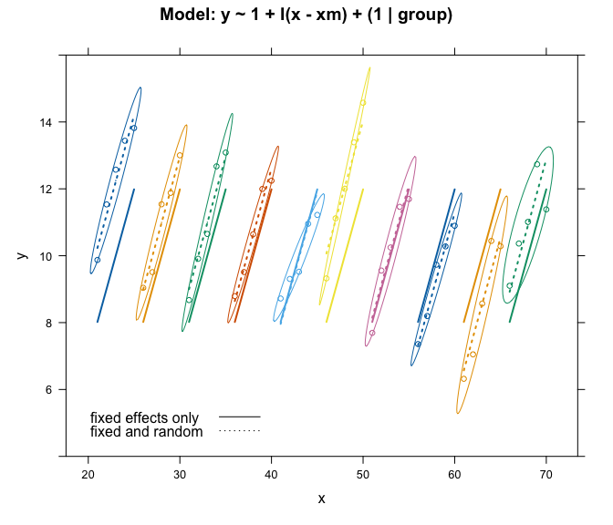

Predictions from the estimated model generating the data.

```r
(plot +
  xyplot(fit ~ x, subset(Data_long, modelcode == "mod3" & effect == "fe"),
         groups=group, type="l", lwd=2) +
  xyplot(fit ~ x, subset(Data_long, modelcode == "mod3" & effect == "re"),
         groups=group, type="l", lwd=2, lty=3)
) |> update(
  main="Model: y ~ 1 + I(x - xm) + (1 | group)",
  ylim=c(4, 16),
  key=list(
    corner=c(0.05, 0.05),
    text=list(c("fixed effects only","fixed and random")),
    lines=list(lty=c(1, 3))))
```

We next carry out case-based cross-validation, which, as we have explained, is based on both fixed and predicted random effects (i.e., BLUPs), and cluster-based cross-validation, which is based on fixed effects only. In order to reduce between-model random variability in comparisons of models, we apply `cv()` to the list of models created by the `models()` function (introduced previously), performing cross-validation with the same folds for each model:

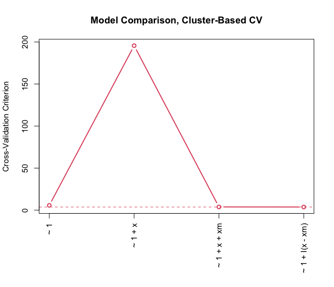

10-fold cluster-based cross-validation comparing random intercept models with varying fixed effects.

```r
modlist <- models("~ 1"=mod.0, "~ 1 + x"=mod.1,
                  "~ 1 + x + xm"=mod.2, "~ 1 + I(x - xm)"=mod.3)
cvs_clusters <- cv(modlist, data=Data, cluster="group", k=10, seed=6449)
plot(cvs_clusters, main="Model Comparison, Cluster-Based CV")
```

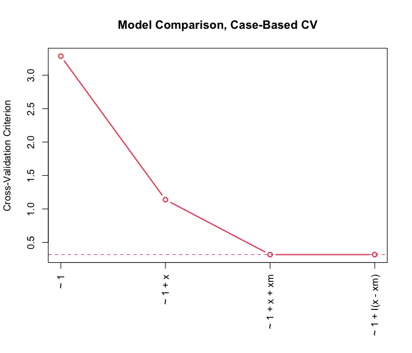

10-fold case-based cross-validation comparing random intercept models with varying fixed effects.

```r
cvs_cases <- cv(modlist, data=Data, seed=9693)
plot(cvs_cases, main="Model Comparison, Case-Based CV")
```

In summary, model `mod.1`, with $x$ alone and without the contextual mean of $x$, is assessed as fitting very poorly by cluster-based CV, but relatively much better by case-based CV. Model `mod.2`, which includes both $x$ and its contextual mean, produces better results using both cluster-based and case-based CV. The data-generating model, `mod.3`, which includes the fixed effect of `x - xm` in place of separate terms in `x` and `xm`, isn’t distinguishable from model `mod.2`, which incldues `x` and `xm` separately, even though `mod.2` has an unnecessary parameter (recall that the population coefficient of `xm` is 0 when `x` is expressed as deviations from the contextual mean). These conclusions are consistent with our observations based on graphing predictions from the various models, and they illustrate the desirability of assessing mixed-effect models at different hierarchical levels.

Sarkar, D. (2008). *Lattice: Multivariate data visualization with r*. Springer. http://lmdvr.r-forge.r-project.org

Sarkar, D., & Andrews, F. (2022). *latticeExtra: Extra graphical utilities based on lattice*. https://CRAN.R-project.org/package=latticeExtra

[^1]: We invite the interested reader to experiment with varying the parameters of our example.
[^2]: We find it convenient to use the **lattice** (Sarkar, 2008) and **latticeExtra** (Sarkar & Andrews, 2022) packages for this and other graphs in this section.